# Assignment 4

[figure not shown]

#### Roll No: AA.SC.P2MCA2107423

#### Date: 15-04-2021

# MCA AI- Business Analytics (S1)

# Assignment 4

### 1. Plot the latitudes and longitudes of any 5 cities in India (include your hometown as well), on the map.

```python
import pandas as pd
import matplotlib.pyplot as plt
import numpy as np
plt.rcParams['axes.facecolor'] = 'white'
import seaborn as sns
sns.set_style('whitegrid')
from shapely.geometry import Point
import plotly.express as px
import chart_studio.plotly as pl
import plotly.graph_objs as gobj
from plotly.offline import download_plotlyjs,init_notebook_mode,plot,iplot
init_notebook_mode(connected=True)
#import geopandas as gpd
#from geopandas import GeoDataFrame
```

```python
list_city_location = [["Delhi", "Delhi", 28.679079, 77.069710],
                     ["Mumbai", "Maharastra", 19.076090, 72.877426],
                     ["Lucknow", "Uttar Pradesh", 26.850000, 80.949997],
                     ["Kolkata", "West Bengal", 22.572645, 88.363892],
                     ["Raipur", "Chhattisgarh", 21.250000, 81.629997],
                     ["Kollam", "Kerala", 8.893212, 76.614143]]
df_cities = pd.DataFrame(list_city_location, columns = ["City", "State", "Latitude", "Longitude"])
df_cities
```

|  | City | State | Latitude | Longitude |
| --- | --- | --- | --- | --- |
| 0 | Delhi | Delhi | 28.679079 | 77.069710 |
| 1 | Mumbai | Maharastra | 19.076090 | 72.877426 |
| 2 | Lucknow | Uttar Pradesh | 26.850000 | 80.949997 |
| 3 | Kolkata | West Bengal | 22.572645 | 88.363892 |
| 4 | Raipur | Chhattisgarh | 21.250000 | 81.629997 |
| 5 | Kollam | Kerala | 8.893212 | 76.614143 |

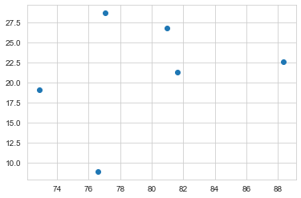

```python
plt.scatter(x=df_cities['Longitude'], y=df_cities['Latitude'])
plt.show()
```

```python
fig = px.scatter_geo(df_cities,lat='Latitude',lon='Longitude')
fig.update_layout(title = 'Indian Cities', title_x=0.5)
fig.show()
```

[interactive chart not shown]

```python
fig = px.choropleth(
    df_cities,
    geojson="https://gist.githubusercontent.com/jbrobst/56c13bbbf9d97d187fea01ca62ea5112/raw/e388c4cae20aa53cb5090210a42ebb9b765c0a36/india_states.geojson",
    featureidkey='properties.ST_NM',
    locations='State',
    color='Latitude',
    color_continuous_scale='Reds'
)

fig.update_geos(fitbounds="locations", visible=True)

fig.show()
```

[interactive chart not shown]

### 3. Table shows the distribution of various ethnic groups in the population of a particular state based on a decennial US. census

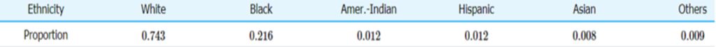

### Five years later a random sample of 2,500 residents of the state was taken, with the results given in Table. Test, at the 1% level of significance, whether there is sufficient evidence in the sample to conclude that the distribution of ethnic groups in this state five years after the census had changed from that in the census year

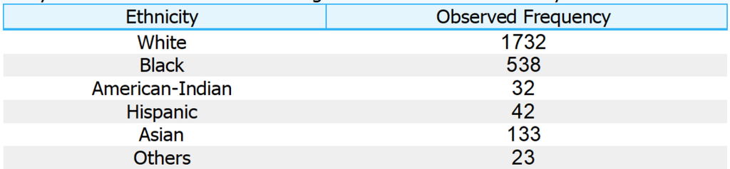

```python
df_Ethnicity = pd.read_csv("C:\spark\MCA\Semester1\E2_BA\Assignment 4\Ethnicity.csv")
df_Ethnicity
```

|  | Ethnicity | Assumed Distribution | Observed Frequency |
| --- | --- | --- | --- |
| 0 | White | 0.743 | 1732 |
| 1 | Black | 0.216 | 538 |
| 2 | American-Indian | 0.012 | 32 |
| 3 | Hispanic | 0.012 | 42 |
| 4 | Asian | 0.008 | 133 |
| 5 | Others | 0.009 | 23 |

### Step 1. The hypotheses of interest in this case can be expressed as

```
    H0: The distribution of ethnic groups has not changed
    Ha: The distribution of ethnic groups has changed
```

### Step 2. The distribution is chi-square.

### Step 3. To compute the value of the test statistic we must first compute the expected number for each row of Table

```python
df_Ethnicity['Expected Frequency'] = 2500 * df_Ethnicity['Assumed Distribution']
df_Ethnicity
```

|  | Ethnicity | Assumed Distribution | Observed Frequency | Expected Frequency |
| --- | --- | --- | --- | --- |
| 0 | White | 0.743 | 1732 | 1857.5 |
| 1 | Black | 0.216 | 538 | 540.0 |
| 2 | American-Indian | 0.012 | 32 | 30.0 |
| 3 | Hispanic | 0.012 | 42 | 30.0 |
| 4 | Asian | 0.008 | 133 | 20.0 |
| 5 | Others | 0.009 | 23 | 22.5 |

```python
df_Ethnicity.info()
```

```
<class 'pandas.core.frame.DataFrame'>
RangeIndex: 6 entries, 0 to 5
Data columns (total 4 columns):
 #   Column                Non-Null Count  Dtype
---  ------                --------------  -----
 0   Ethnicity             6 non-null      object
 1   Assumed Distribution  6 non-null      float64
 2   Observed Frequency    6 non-null      int64
 3   Expected Frequency    6 non-null      float64
dtypes: float64(2), int64(1), object(1)
memory usage: 320.0+ bytes
```

```python
sum = 0
for i in df_Ethnicity.index:
    sq = np.power((df_Ethnicity.loc[i, 'Observed Frequency'] - df_Ethnicity.loc[i, 'Expected Frequency']), 2) / df_Ethnicity.loc[i, 'Expected Frequency']
    sum = sum + sq
```

```python
sum
```

```
651.881125068541
```

Since the random variable takes six values, I = 6. Thus the test statistic follows the chi-square distribution with df=6−1=5 degrees of freedom.

Since the test is right-tailed, the critical value is X^2(0.01). Reading from below figure, X^2(0.01)=15.086, so the rejection region is [15.086,∞).

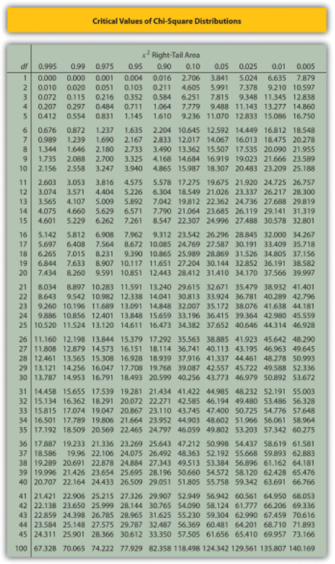

Since 651.881 > 15.086 the decision is to reject the null hypothesis.

The data provide sufficient evidence, at the 1% level of significance, to conclude that the ethnic distribution in this state has changed in the five years since the U.S. census.